# R Notebook

```r
library(car)
library(MASS)
library(data.table)
library(tidyverse)
library(magrittr)
# library(Rtools)
library(retimes)
library(boot)
library(zoo)
library(broom.mixed)
library(lme4)
library(lmerTest)
library(sjPlot)
library(emmeans)

#behavioural data: RT and error rates
rtimes <- readRDS('data/rtimes_errors.rds')
error_rates <- readRDS('data/error_rates.rds')

#neural data
df <- readRDS('data/psicat_neural.rds')

#set contrast options
options(contrasts = c("contr.sum","contr.poly"))
```

# Behavioural results

Trial-wise *reaction times* are used to find subject-level parameters of ex-Gaussian distributions. These parameters are then used as DVs in LMMs. Subject-level *error rates* are DVs in logistic regression (GLMM).

## Ex-Gaussian distribution parameters

Estimating mu, sigma, tau for each participant and condition.  
**mu**: mean of Gaussian distribution  
**sigma**: SD of Gaussian distribution  
**tau**: tail (greater tau -> more long RTs -> positive skew)

### Plot parameter distributions

`r`r sbj_params_ml %>% gather(var, value, mu:tau) %>% ggplot(aes(value, fill=interaction(congruency, shape))) + geom_density(alpha=.4) + facet_wrap(var~group, ncol=2) + theme_bw()

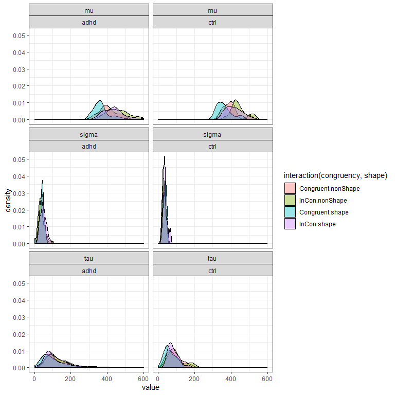

## Fitting lmer with ex-Gaussian parameters

`r`r sbj_params_ml <- sbj_params_ml %>% mutate(group = relevel(factor(group), ref = ), congruency = relevel(factor(congruency), ref = ), shape = relevel(factor(shape), ref = ))

### mu

`r`r mmu <- lmer(mu ~ group*shape*congruency + (1|shape:Subject) + (1|congruency:Subject) + (1|Subject), data=sbj_params_ml) summary(mmu)

```
Linear mixed model fit by REML. t-tests use Satterthwaite's method ['lmerModLmerTest']
Formula: mu ~ group * shape * congruency + (1 | shape:Subject) + (1 |
    congruency:Subject) + (1 | Subject)
   Data: sbj_params_ml

REML criterion at convergence: 2696

Scaled residuals:
     Min       1Q   Median       3Q      Max
-1.98231 -0.39006 -0.00561  0.35897  2.29753

Random effects:
 Groups             Name        Variance Std.Dev.
 shape:Subject      (Intercept)  353.0   18.79
 congruency:Subject (Intercept)  146.4   12.10
 Subject            (Intercept) 1946.2   44.12
 Residual                        230.5   15.18
Number of obs: 280, groups:  shape:Subject, 140; congruency:Subject, 140; Subject, 70

Fixed effects:
                          Estimate Std. Error       df t value Pr(>|t|)
(Intercept)               410.2368     6.4910  67.9985  63.201  < 2e-16 ***
group1                     -5.6404     6.4910  67.9985  -0.869   0.3879
shape1                    -15.1045     2.0921  68.0004  -7.220 5.69e-10 ***
congruency1               -27.9599     1.5638  68.0002 -17.880  < 2e-16 ***
group1:shape1              -0.2503     2.0921  68.0004  -0.120   0.9051
group1:congruency1          3.3247     1.5638  68.0002   2.126   0.0371 *
shape1:congruency1         -2.5311     1.0379  68.0002  -2.439   0.0174 *
group1:shape1:congruency1  -0.1439     1.0379  68.0002  -0.139   0.8902
---
Signif. codes:  0 ‘***’ 0.001 ‘**’ 0.01 ‘*’ 0.05 ‘.’ 0.1 ‘ ’ 1

Correlation of Fixed Effects:
            (Intr) group1 shape1 cngrn1 grp1:s1 grp1:c1 shp1:1
group1      0.486
shape1      0.000  0.000
congruency1 0.000  0.000  0.000
group1:shp1 0.000  0.000  0.486  0.000
grp1:cngrn1 0.000  0.000  0.000  0.486  0.000
shp1:cngrn1 0.000  0.000  0.000  0.000  0.000   0.000
grp1:shp1:1 0.000  0.000  0.000  0.000  0.000   0.000   0.486
```

`r`r plot_model(mmu, type = )[[4]]

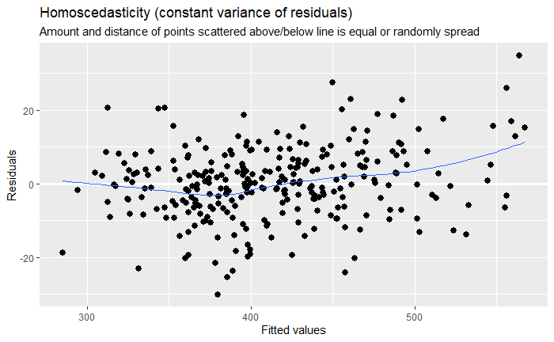

### sigma

**Note warning: singular fit**

`r`r msig <- lmer(sigma ~ group*shape*congruency + (1|shape:Subject) + (1|congruency:Subject) + (1|Subject), data=sbj_params_ml)

```
boundary (singular) fit: see ?isSingular
```

`r`r summary(msig)

```
Linear mixed model fit by REML. t-tests use Satterthwaite's method ['lmerModLmerTest']
Formula: sigma ~ group * shape * congruency + (1 | shape:Subject) + (1 |
    congruency:Subject) + (1 | Subject)
   Data: sbj_params_ml

REML criterion at convergence: 2238

Scaled residuals:
    Min      1Q  Median      3Q     Max
-3.3335 -0.5074 -0.0433  0.5395  4.1650

Random effects:
 Groups             Name        Variance  Std.Dev.
 shape:Subject      (Intercept) 4.979e-06  0.002231
 congruency:Subject (Intercept) 0.000e+00  0.000000
 Subject            (Intercept) 5.339e+01  7.306870
 Residual                       1.493e+02 12.220036
Number of obs: 280, groups:  shape:Subject, 140; congruency:Subject, 140; Subject, 70

Fixed effects:
                          Estimate Std. Error       df t value Pr(>|t|)
(Intercept)                38.2898     1.3024  67.9999  29.400  < 2e-16 ***
group1                     -3.5267     1.3024  67.9999  -2.708  0.00856 **
shape1                      2.2272     0.8355 203.9941   2.666  0.00830 **
congruency1                -0.6398     0.8355 203.9986  -0.766  0.44467
group1:shape1               0.4167     0.8355 203.9941   0.499  0.61848
group1:congruency1          0.6362     0.8355 203.9986   0.762  0.44721
shape1:congruency1         -1.9137     0.8355 203.9986  -2.291  0.02301 *
group1:shape1:congruency1   0.7160     0.8355 203.9986   0.857  0.39245
---
Signif. codes:  0 ‘***’ 0.001 ‘**’ 0.01 ‘*’ 0.05 ‘.’ 0.1 ‘ ’ 1

Correlation of Fixed Effects:
            (Intr) group1 shape1 cngrn1 grp1:s1 grp1:c1 shp1:1
group1      0.486
shape1      0.000  0.000
congruency1 0.000  0.000  0.000
group1:shp1 0.000  0.000  0.486  0.000
grp1:cngrn1 0.000  0.000  0.000  0.486  0.000
shp1:cngrn1 0.000  0.000  0.000  0.000  0.000   0.000
grp1:shp1:1 0.000  0.000  0.000  0.000  0.000   0.000   0.486
convergence code: 0
boundary (singular) fit: see ?isSingular
```

`r`r #plot_model(msig, type = )[[4]]

### tau

`r`r mtau <- lmer(tau ~ group*shape*congruency + (1|shape:Subject) + (1|congruency:Subject) + (1|Subject), data=sbj_params_ml) summary(mtau)

```
Linear mixed model fit by REML. t-tests use Satterthwaite's method ['lmerModLmerTest']
Formula: tau ~ group * shape * congruency + (1 | shape:Subject) + (1 |
    congruency:Subject) + (1 | Subject)
   Data: sbj_params_ml

REML criterion at convergence: 2784.6

Scaled residuals:
    Min      1Q  Median      3Q     Max
-3.6218 -0.3933 -0.0775  0.4350  3.3832

Random effects:
 Groups             Name        Variance Std.Dev.
 shape:Subject      (Intercept)  222.78  14.93
 congruency:Subject (Intercept)   15.61   3.95
 Subject            (Intercept) 3075.05  55.45
 Residual                        523.62  22.88
Number of obs: 280, groups:  shape:Subject, 140; congruency:Subject, 140; Subject, 70

Fixed effects:
                          Estimate Std. Error       df t value Pr(>|t|)
(Intercept)               100.9018     7.8847  67.9978  12.797  < 2e-16 ***
group1                    -17.9364     7.8847  67.9978  -2.275   0.0261 *
shape1                    -10.1079     2.1284  68.0007  -4.749 1.09e-05 ***
congruency1                -2.9037     1.6104  68.0058  -1.803   0.0758 .
group1:shape1               0.5898     2.1284  68.0007   0.277   0.7825
group1:congruency1         -1.6461     1.6104  68.0058  -1.022   0.3103
shape1:congruency1         -3.3341     1.5644  68.0074  -2.131   0.0367 *
group1:shape1:congruency1  -1.8611     1.5644  68.0074  -1.190   0.2383
---
Signif. codes:  0 ‘***’ 0.001 ‘**’ 0.01 ‘*’ 0.05 ‘.’ 0.1 ‘ ’ 1

Correlation of Fixed Effects:
            (Intr) group1 shape1 cngrn1 grp1:s1 grp1:c1 shp1:1
group1      0.486
shape1      0.000  0.000
congruency1 0.000  0.000  0.000
group1:shp1 0.000  0.000  0.486  0.000
grp1:cngrn1 0.000  0.000  0.000  0.486  0.000
shp1:cngrn1 0.000  0.000  0.000  0.000  0.000   0.000
grp1:shp1:1 0.000  0.000  0.000  0.000  0.000   0.000   0.486
```

`r`r #plot_model(mtau, type = )[[4]]

### tau (log model)

`r`r mtau.log <- lmer(log(tau) ~ group*shape*congruency + (1|shape:Subject) + (1|congruency:Subject) + (1|Subject), data=sbj_params_ml) summary(mtau.log)

```
Linear mixed model fit by REML. t-tests use Satterthwaite's method ['lmerModLmerTest']
Formula: log(tau) ~ group * shape * congruency + (1 | shape:Subject) +
    (1 | congruency:Subject) + (1 | Subject)
   Data: sbj_params_ml

REML criterion at convergence: 327.2

Scaled residuals:
    Min      1Q  Median      3Q     Max
-7.7035 -0.3496  0.0349  0.4177  2.4095

Random effects:
 Groups             Name        Variance Std.Dev.
 shape:Subject      (Intercept) 0.018481 0.13594
 congruency:Subject (Intercept) 0.003679 0.06066
 Subject            (Intercept) 0.194189 0.44067
 Residual                       0.080813 0.28428
Number of obs: 280, groups:  shape:Subject, 140; congruency:Subject, 140; Subject, 70

Fixed effects:
                           Estimate Std. Error        df t value Pr(>|t|)
(Intercept)                4.470194   0.064927 67.996312  68.849  < 2e-16 ***
group1                    -0.154492   0.064927 67.996312  -2.379  0.02015 *
shape1                    -0.118601   0.023463 68.002136  -5.055 3.47e-06 ***
congruency1               -0.037297   0.020301 68.006855  -1.837  0.07055 .
group1:shape1              0.008631   0.023463 68.002136   0.368  0.71413
group1:congruency1        -0.031897   0.020301 68.006855  -1.571  0.12077
shape1:congruency1        -0.055106   0.019435 68.004795  -2.835  0.00602 **
group1:shape1:congruency1 -0.038049   0.019435 68.004795  -1.958  0.05437 .
---
Signif. codes:  0 ‘***’ 0.001 ‘**’ 0.01 ‘*’ 0.05 ‘.’ 0.1 ‘ ’ 1

Correlation of Fixed Effects:
            (Intr) group1 shape1 cngrn1 grp1:s1 grp1:c1 shp1:1
group1      0.486
shape1      0.000  0.000
congruency1 0.000  0.000  0.000
group1:shp1 0.000  0.000  0.486  0.000
grp1:cngrn1 0.000  0.000  0.000  0.486  0.000
shp1:cngrn1 0.000  0.000  0.000  0.000  0.000   0.000
grp1:shp1:1 0.000  0.000  0.000  0.000  0.000   0.000   0.486
```

`r`r #plot_model(mtau.log, type = )[[4]]

### Plot fixed effects

`r`r new_data <- expand.grid(shape = c(‘shape’, ‘nonShape’), congruency = c(‘Congruent’, ‘InCon’), group = c(‘adhd’, ‘ctrl’))

models <- list(mmu = mmu, msig = msig, mtau = mtau, mtau.log = mtau.log)

p <- lapply(seq_along(models), function(i) { cbind(new_data, rtime = predict(models[[i]], newdata = new_data, re.form=NA)) %>% ggplot(aes(congruency, rtime, linetype=shape)) + geom_point() + geom_line(aes(group=shape),size=1) + facet_wrap(~group) + theme_bw() + ggtitle(names(models)[i]) })

p

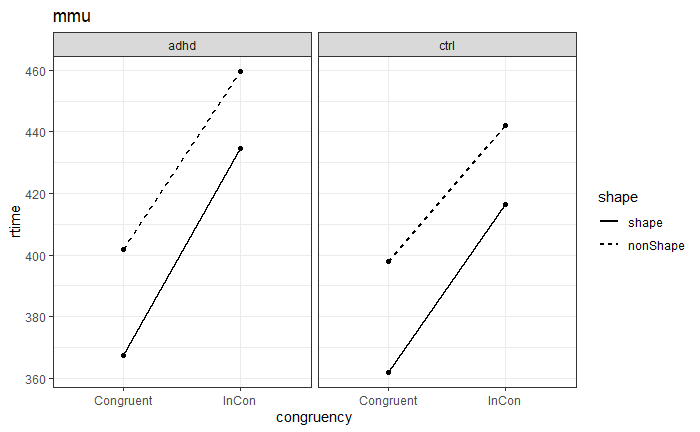

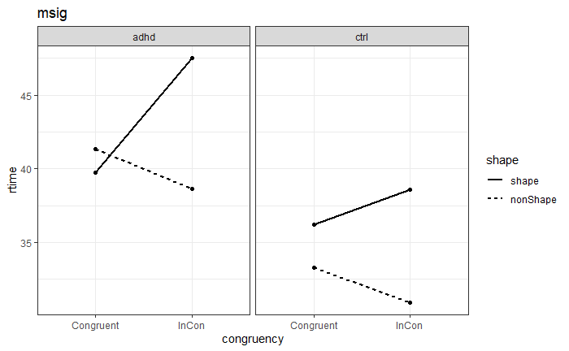

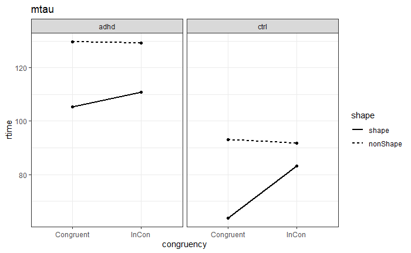

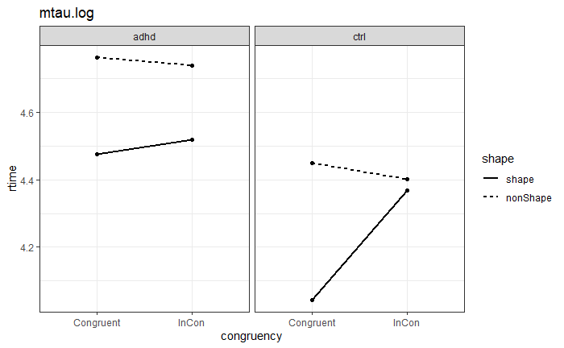

### Contrasts

So far for mtau.log model only.  
**TODO**: Which are relevant for RQs?

`r`r means.int <- emmeans(mtau.log, specs = c(, , )) means.int

```
 group shape    congruency emmean     SE  df lower.CL upper.CL
 ctrl  shape    Congruent    4.04 0.1285 114     3.79     4.30
 adhd  shape    Congruent    4.47 0.0756 114     4.33     4.62
 ctrl  nonShape Congruent    4.45 0.1285 114     4.20     4.70
 adhd  nonShape Congruent    4.76 0.0756 114     4.61     4.91
 ctrl  shape    InCon        4.37 0.1285 114     4.11     4.62
 adhd  shape    InCon        4.52 0.0756 114     4.37     4.67
 ctrl  nonShape InCon        4.40 0.1285 114     4.15     4.66
 adhd  nonShape InCon        4.74 0.0756 114     4.59     4.89

Degrees-of-freedom method: kenward-roger
Results are given on the log (not the response) scale.
Confidence level used: 0.95
```

`r`r pairs(means.int) #all pairs

```
 contrast                                          estimate     SE  df t.ratio p.value
 ctrl,shape,Congruent - adhd,shape,Congruent        -0.4316 0.1491 114 -2.895  0.0831
 ctrl,shape,Congruent - ctrl,nonShape,Congruent     -0.4063 0.1050 131 -3.868  0.0042
 ctrl,shape,Congruent - adhd,nonShape,Congruent     -0.7202 0.1491 114 -4.831  0.0001
 ctrl,shape,Congruent - ctrl,shape,InCon            -0.3247 0.0969 136 -3.351  0.0226
 ctrl,shape,Congruent - adhd,shape,InCon            -0.4765 0.1491 114 -3.197  0.0369
 ctrl,shape,Congruent - ctrl,nonShape,InCon         -0.3583 0.1070 133 -3.350  0.0228
 ctrl,shape,Congruent - adhd,nonShape,InCon         -0.6969 0.1491 114 -4.675  0.0002
 adhd,shape,Congruent - ctrl,nonShape,Congruent      0.0254 0.1491 114  0.170  1.0000
 adhd,shape,Congruent - adhd,nonShape,Congruent     -0.2886 0.0618 131 -4.670  0.0002
 adhd,shape,Congruent - ctrl,shape,InCon             0.1069 0.1491 114  0.717  0.9963
 adhd,shape,Congruent - adhd,shape,InCon            -0.0449 0.0570 136 -0.788  0.9935
 adhd,shape,Congruent - ctrl,nonShape,InCon          0.0733 0.1491 114  0.492  0.9997
 adhd,shape,Congruent - adhd,nonShape,InCon         -0.2653 0.0629 133 -4.215  0.0012
 ctrl,nonShape,Congruent - adhd,nonShape,Congruent  -0.3139 0.1491 114 -2.106  0.4175
 ctrl,nonShape,Congruent - ctrl,shape,InCon          0.0816 0.1070 133  0.762  0.9947
 ctrl,nonShape,Congruent - adhd,shape,InCon         -0.0703 0.1491 114 -0.471  0.9998
 ctrl,nonShape,Congruent - ctrl,nonShape,InCon       0.0479 0.0969 136  0.495  0.9997
 ctrl,nonShape,Congruent - adhd,nonShape,InCon      -0.2906 0.1491 114 -1.950  0.5203
 adhd,nonShape,Congruent - ctrl,shape,InCon          0.3955 0.1491 114  2.653  0.1483
 adhd,nonShape,Congruent - adhd,shape,InCon          0.2437 0.0629 133  3.872  0.0041
 adhd,nonShape,Congruent - ctrl,nonShape,InCon       0.3619 0.1491 114  2.427  0.2384
 adhd,nonShape,Congruent - adhd,nonShape,InCon       0.0233 0.0570 136  0.409  0.9999
 ctrl,shape,InCon - adhd,shape,InCon                -0.1518 0.1491 114 -1.018  0.9708
 ctrl,shape,InCon - ctrl,nonShape,InCon             -0.0336 0.1050 131 -0.320  1.0000
 ctrl,shape,InCon - adhd,nonShape,InCon             -0.3722 0.1491 114 -2.497  0.2075
 adhd,shape,InCon - ctrl,nonShape,InCon              0.1182 0.1491 114  0.793  0.9932
 adhd,shape,InCon - adhd,nonShape,InCon             -0.2204 0.0618 131 -3.566  0.0116
 ctrl,nonShape,InCon - adhd,nonShape,InCon          -0.3386 0.1491 114 -2.271  0.3187

Degrees-of-freedom method: kenward-roger
Results are given on the log (not the response) scale.
P value adjustment: tukey method for comparing a family of 8 estimates
```

`r`r cont <- contrast(means.int, list(shape_nonshape = c(1,-1)), by=c(, )) #Estimate is the same as from effects library, but t value is used instead of z #contrast(means.int, list(shape_nonshape = c(1,-1)), simple=) # this is the same thing; either specify simple or by #coef(cont) cont

```
congruency = Congruent, group = ctrl:
 contrast       estimate     SE  df t.ratio p.value
 shape_nonshape  -0.4063 0.1050 131 -3.868  0.0002

congruency = Congruent, group = adhd:
 contrast       estimate     SE  df t.ratio p.value
 shape_nonshape  -0.2886 0.0618 131 -4.670  <.0001

congruency = InCon, group = ctrl:
 contrast       estimate     SE  df t.ratio p.value
 shape_nonshape  -0.0336 0.1050 131 -0.320  0.7493

congruency = InCon, group = adhd:
 contrast       estimate     SE  df t.ratio p.value
 shape_nonshape  -0.2204 0.0618 131 -3.566  0.0005

Degrees-of-freedom method: kenward-roger
Results are given on the log (not the response) scale.
```

`r`r #also same as: #means.int <- emmeans(mtau.log, specs = c(, , ), by = c(, )) #cont <- contrast(means.int, list(shape_nonshape = c(1,-1))) # OR pairs(means.int)

#or: #lsm <- emmeans(mtau.log, ~shape|congruency:group) #shape contrasts at each level of congruency and group #cont <- contrast(lsm, interaction = ) # OR pairs(lsm)

`r`r

emms1 <- emmeans(mtau.log, ~ shape*congruency|group) #shape-congruency interaction for each group #emmip(mtau.log, shape ~ congruency | group, CIs = T) con1 <- contrast(emms1, interaction = ) #interaction effects for each group. Tukey adjustment by default; same as interaction contrasts from joint_tests (below) pairs(con1, by = NULL) #compare interaction effects pairwise (between groups). same as group:shape:congruency joint_tests without by parameter

```
 contrast                                                                          estimate
 shape - nonShape,Congruent - InCon,ctrl - shape - nonShape,Congruent - InCon,adhd   -0.304
    SE df t.ratio p.value
 0.155 68 -1.958  0.0544

Degrees-of-freedom method: kenward-roger
Results are given on the log (not the response) scale.
```

`r`r #interaction contrasts for all effects joint_tests(mtau.log, by = )

```
group = ctrl:
 model term       df1 df2 F.ratio p.value
 shape              1  68   7.393 0.0083
 congruency         1  68   3.910 0.0521
 shape:congruency   1  68   7.731 0.0070

group = adhd:
 model term       df1 df2 F.ratio p.value
 shape              1  68  28.590 <.0001
 congruency         1  68   0.069 0.7939
 shape:congruency   1  68   0.749 0.3899
```

`r`r joint_tests(mtau.log) #same as fixed effects of lmer summary

```
 model term             df1 df2 F.ratio p.value
 group                    1  68   5.662 0.0201
 shape                    1  68  25.552 <.0001
 congruency               1  68   3.375 0.0705
 group:shape              1  68   0.135 0.7141
 group:congruency         1  68   2.469 0.1208
 shape:congruency         1  68   8.039 0.0060
 group:shape:congruency   1  68   3.833 0.0544
```

### Bootstrapping lmer estimates

`r`r bootstrap.estimates <- function(model) { cb <- bootMer(model, FUN=fixef, nsim=1000 #.progress = , PBargs = list(style=3) ) cb }

bootstrap.estimate.plot <- function(cb, model) { boot_ci <- lapply(2:8, function(b) boot.ci(cb, type = , index=b)$percent)

ci <- do.call(rbind, boot_ci) td <- broom.mixed::tidy(model)[2:8,]  
td$conf.low <- ci[, 4] td$conf.high <- ci[, 5] g <- ggplot(td, aes(term, estimate)) + geom_point() + geom_errorbar(aes(ymin = conf.low, ymax = conf.high), width=.1) + coord_flip() + geom_hline(aes(yintercept=0), linetype= ) + theme_bw() g }

`r`r b.models <- lapply(models, bootstrap.estimates)

lapply(seq_along(models), function(i) { p <- bootstrap.estimate.plot(b.models[[i]], models[[i]]) p + ggtitle(names(models)[i]) })

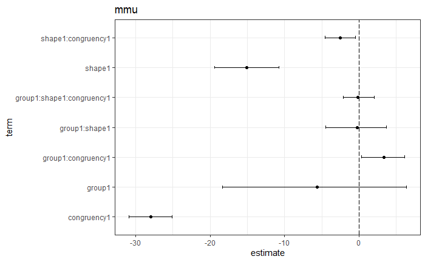

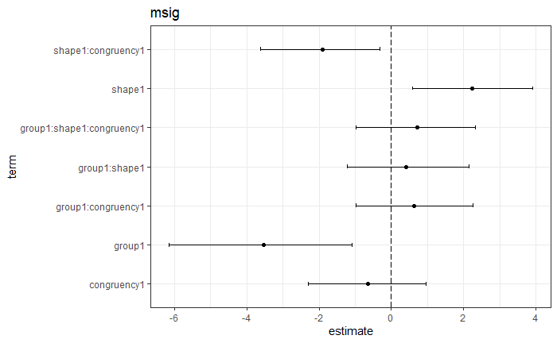

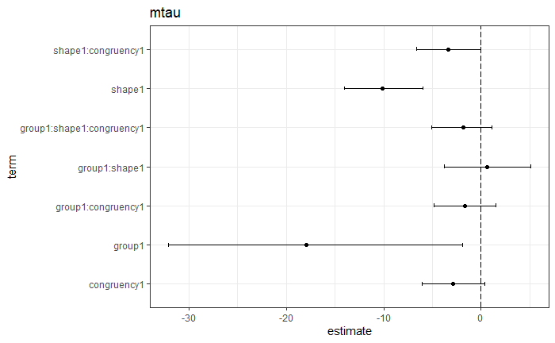

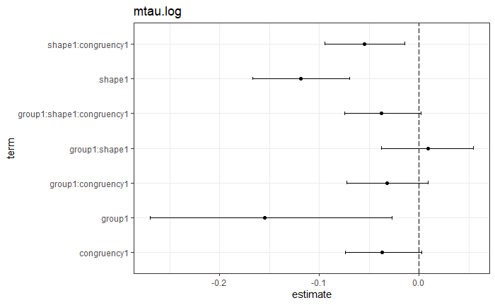

## Error rate analysis

Using glmer logistic regression with error rate as DV and number of trials as weights.  
(with optimizer to solve convergence issue; producing very similar results but without warnings)

`r`r glmm.fit <- glmer(err ~ group*shape*congruency + (1|shape:Subject) + (1|congruency:Subject) + (1|Subject), family = binomial(logit), data=error_rates, weights=n, glmerControl(optimizer = ‘nlminbwrap’)) summary(glmm.fit)

```
Generalized linear mixed model fit by maximum likelihood (Laplace Approximation) ['glmerMod']
 Family: binomial  ( logit )
Formula: err ~ group * shape * congruency + (1 | shape:Subject) + (1 |
    congruency:Subject) + (1 | Subject)
   Data: error_rates
Weights: n
Control: glmerControl(optimizer = \nlminbwrap\)

     AIC      BIC   logLik deviance df.resid
  1109.3   1149.3   -543.6   1087.3      269

Scaled residuals:
    Min      1Q  Median      3Q     Max
-1.4136 -0.6279 -0.1308  0.3661  1.5291

Random effects:
 Groups             Name        Variance Std.Dev.
 shape:Subject      (Intercept) 0.5139   0.7169
 congruency:Subject (Intercept) 0.1431   0.3783
 Subject            (Intercept) 0.5809   0.7622
Number of obs: 280, groups:  shape:Subject, 140; congruency:Subject, 140; Subject, 70

Fixed effects:
                           Estimate Std. Error z value Pr(>|z|)
(Intercept)               -4.656157   0.149885 -31.065  < 2e-16 ***
group1                    -0.154028   0.146938  -1.048   0.2945
shape1                     0.206716   0.094995   2.176   0.0296 *
congruency1               -0.452956   0.070982  -6.381 1.76e-10 ***
group1:shape1             -0.003055   0.094872  -0.032   0.9743
group1:congruency1        -0.007589   0.070790  -0.107   0.9146
shape1:congruency1        -0.222859   0.056838  -3.921 8.82e-05 ***
group1:shape1:congruency1 -0.103174   0.056892  -1.813   0.0698 .
---
Signif. codes:  0 ‘***’ 0.001 ‘**’ 0.01 ‘*’ 0.05 ‘.’ 0.1 ‘ ’ 1

Correlation of Fixed Effects:
            (Intr) group1 shape1 cngrn1 grp1:s1 grp1:c1 shp1:1
group1       0.486
shape1      -0.024 -0.013
congruency1  0.137  0.074  0.092
group1:shp1 -0.011 -0.030  0.527  0.085
grp1:cngrn1  0.081  0.125  0.084  0.575  0.092
shp1:cngrn1  0.077  0.066  0.206 -0.092  0.125  -0.046
grp1:shp1:1  0.073  0.069  0.126 -0.043  0.205  -0.093   0.638
```

`r`r # help() # glmm.all <- allFit(glmm.fit) #try all available optimizers to solve convergence issue # ss <- summary(glmm.all)

glmm.probs <- cbind(error_rates, pred = predict(glmm.fit, type = ))

glmm.probs %>% gather(var, value, err, pred) %>% unite(cond, congruency, shape) %>% ggplot(aes(cond, value, color=var)) + geom_boxplot() + facet_wrap(~group) + theme_bw() + ggtitle(‘Actual and predicted error rates’) + theme(axis.text.x = element_text(angle = 15))

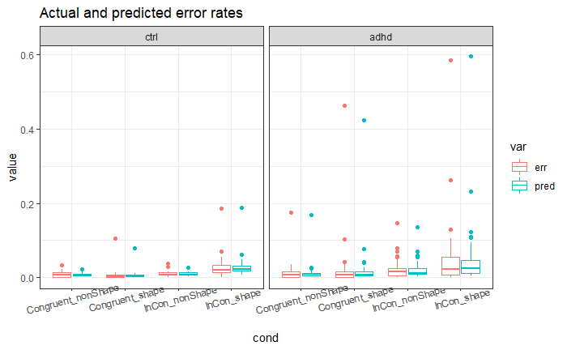

**TODO**: Post-hoc tests, diagnostics, bootstrapping?

## Trial-wise RTs over time

Note: some subjects have a LOT of errors (black dots), e.g. 1057P.

`r`r rtimes %>% mutate(error_hl = ifelse(error == 1, TTime, NA_real_)) %>% ggplot(aes(Trial, TTime, color=group, group=Subject)) + geom_line(size=1) + theme_bw() + geom_point(aes(Trial, error_hl), col=, size=.8) + facet_wrap(~Subject, ncol=1)

[figure not shown]

# Neural results: ERPs

Subject 2011C excluded because of bad data.

(N1: occipital, P3a: vertex, P3b: parietal)  
H3P3a, H3P3b, H4pN1 with baseline -250…-150  
H4tN1, H4tP3 with baseline -250…0

Questions of congruency: pre-primer baseline  
Questions of shape: separate baselines

H3 (congruency):  
P3a: baseline -250…-150, latency from target –> “P3aprimer”  
P3b: baseline -250…-150, latency from target –> “P3b”

H4 (shape):  
N1 primer: baseline -250…-150, latency from primer –> “N1primer”  
N1 target: baseline -250…0, latency from target –> “N1target” (in each congruency condition)  
P3a: baseline -250…0, latency from target –> “P3atarget” (in each congruency condition)

(Note “P3aprimer” can be a misleading name because latency is calculated from target onset.)

## Local peaks within windows

If multiple peaks are found, we need a decision rule:  
- choose latency of the most negative amplitude?  
- choose latency that captures both shape and nonshape peaks?  
- something else?

`r`r #Peak amplitude and latency values for N1primer. df %>% filter(roi == ‘occipital’, pritar == ‘primer’) %>% group_by(group, sbj, shape, time) %>% summarise(mean = mean(value)) %>% arrange(group, sbj, shape, time) %>% group_by(group, sbj, shape) %>% mutate(roll = rollapply(as.zoo(mean), 3, function(x) which.min(x)==2, fill=NA)) %>% filter(between(time, -50, 50), roll==T) r NA

| group | sbj | shape | time | mean | roll |
| --- | --- | --- | --- | --- | --- |
| adhd | 1001P | nonshape | 21.87500 | -2.353577e-01 | TRUE |
| adhd | 1002P | nonshape | -36.71875 | 1.724546e+00 | TRUE |
| adhd | 1002P | nonshape | 25.78125 | 6.812590e-01 | TRUE |
| adhd | 1002P | shape | -28.90625 | 1.128983e+00 | TRUE |
| adhd | 1002P | shape | 25.78125 | 7.957903e-01 | TRUE |
| adhd | 1003P | nonshape | -32.81250 | 2.631047e-01 | TRUE |
| adhd | 1003P | nonshape | -13.28125 | 2.775362e-01 | TRUE |
| adhd | 1003P | shape | -5.46875 | -5.271810e-01 | TRUE |
| adhd | 1007P | nonshape | -17.18750 | 6.060929e-01 | TRUE |
| adhd | 1007P | nonshape | 37.50000 | 1.235484e+00 | TRUE |

[output cut: 172 more lines]

**Another (simpler) option would be to use a fixed window that is wide enough (100ms?) and calculate mean amplitude from that, instead of using subject-wise windows.**

#### Testing with N1primer

```r
df %>%
  filter(roi == 'occipital',
         pritar == 'primer') %>%
  group_by(group, sbj, shape, time) %>%
  summarise(mean = mean(value)) %>%
  arrange(group, sbj, shape, time) %>%
  group_by(group, sbj, shape) %>%
  mutate(roll =  rollapply(as.zoo(mean), 3, function(x) which.min(x)==2, fill=NA)) %>%
  filter(between(time, -50, 50), roll==T) %>%
  group_by(group, sbj) %>%
  filter(mean == min(mean,na.rm=T)) %>%
  rename(peak_lat = time) %>%
  ungroup %>%
  select(group, sbj, peak_lat) -> N1primer_times
```

[output not shown]

Using fixed window of 100ms (-50…50 ms or -25…75 ms):

`r`r df %>% filter(roi == ‘occipital’, pritar == ‘primer’) %>% group_by(group, sbj, shape, time) %>% summarise(mean = mean(value)) %>% filter(between(time, -50, +50)) %>% group_by(group, sbj, shape) %>% summarise(mean_amp = mean(mean)) %>% spread(shape, mean_amp) %>% mutate(shape_diff = nonshape - shape) %>% gather(var, value, nonshape:shape_diff) %>% ggplot(aes(group, value)) + geom_violin(alpha=.4) + facet_wrap(~var) + theme_bw() + ggtitle(‘-50…50’) + scale_y_continuous(limits = c(-10, 10))

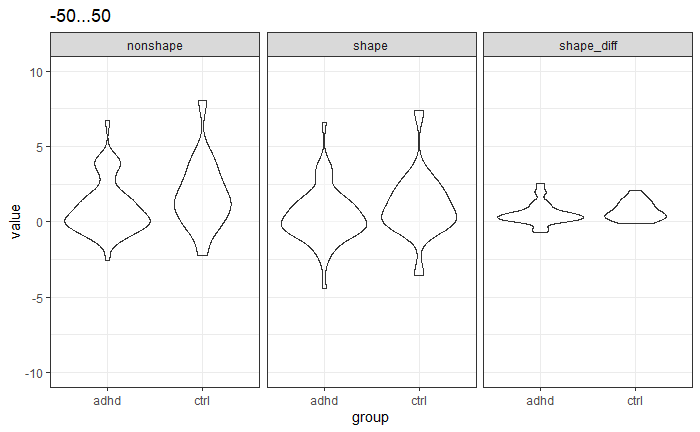

`r`r

df %>% filter(roi == ‘occipital’, pritar == ‘primer’) %>% group_by(group, sbj, shape, time) %>% summarise(mean = mean(value)) %>% filter(between(time, -25, +75)) %>% group_by(group, sbj, shape) %>% summarise(mean_amp = mean(mean)) %>% spread(shape, mean_amp) %>% mutate(shape_diff = nonshape - shape) %>% gather(var, value, nonshape:shape_diff) %>% ggplot(aes(group, value)) + geom_violin(alpha=.4) + facet_wrap(~var) + theme_bw() + ggtitle(‘-25…75’) + scale_y_continuous(limits = c(-10, 10))

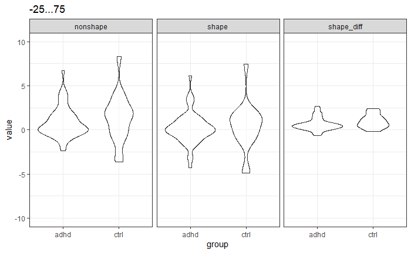

**TODO**: Select final procedure for mean amplitudes, make models according to RQs.